# Machine Learning: AllLife Bank Personal Loan Campaign

## Cost-complexity Pruning

- Cost complexity pruning helps to find the optimal tree size by balancing the trade-off between tree complexity and its accuracy on the training data.
- The ccp_alpha parameter determines the strength of the pruning.

```python
# Perform cost complexity pruning on the decision tree

clf = DecisionTreeClassifier(random_state=1)
path = clf.cost_complexity_pruning_path(X_train, y_train)
ccp_alphas, impurities = path.ccp_alphas, path.impurities
```

```python
# Display the cost complexity pruning path as a DataFrame
pd.DataFrame(path)
```

|  | ccp_alphas | impurities |
| --- | --- | --- |
| 0 | 0.000000 | 0.000000 |
| 1 | 0.000186 | 0.001114 |
| 2 | 0.000187 | 0.001675 |
| 3 | 0.000214 | 0.002104 |
| 4 | 0.000216 | 0.002750 |
| 5 | 0.000268 | 0.003824 |
| 6 | 0.000359 | 0.004900 |
| 7 | 0.000381 | 0.005280 |
| 8 | 0.000381 | 0.005661 |
| 9 | 0.000381 | 0.006042 |
| 10 | 0.000476 | 0.006519 |
| 11 | 0.000527 | 0.007046 |
| 12 | 0.000582 | 0.007628 |
| 13 | 0.000593 | 0.008813 |
| 14 | 0.000641 | 0.011379 |
| 15 | 0.000769 | 0.014456 |
| 16 | 0.000882 | 0.017985 |
| 17 | 0.001552 | 0.019536 |
| 18 | 0.002333 | 0.021869 |
| 19 | 0.003024 | 0.024893 |
| 20 | 0.003294 | 0.028187 |
| 21 | 0.006473 | 0.034659 |
| 22 | 0.023866 | 0.058525 |
| 23 | 0.056365 | 0.171255 |

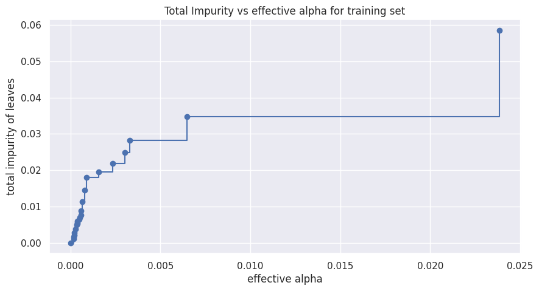

```python
# Create a figure and axis object with specified size
fig, ax = plt.subplots(figsize=(10, 5))

# Plot the relationship between ccp_alphas and impurities
# Use markers for data points and step-style for the line
ax.plot(ccp_alphas[:-1], impurities[:-1], marker="o", drawstyle="steps-post")

# Set the x-axis label
ax.set_xlabel("effective alpha")

# Set the y-axis label
ax.set_ylabel("total impurity of leaves")

# Set the title of the plot
ax.set_title("Total Impurity vs effective alpha for training set")

# Display the plot
plt.show()
```

```python
# Initialize an empty list to store the decision tree classifiers
clfs = []

# Loop through each value of ccp_alpha
for ccp_alpha in ccp_alphas:
    # Create a DecisionTreeClassifier with the current ccp_alpha and a fixed random_state for reproducibility
    clf = DecisionTreeClassifier(random_state=1, ccp_alpha=ccp_alpha)

    # Fit the classifier to the training data (X_train and y_train)
    clf.fit(X_train, y_train)

    # Append the fitted classifier to the list of classifiers
    clfs.append(clf)

# Print the number of nodes in the last decision tree and its corresponding ccp_alpha value
print(
    "Number of nodes in the last tree is: {} with ccp_alpha: {}".format(
        clfs[-1].tree_.node_count, ccp_alphas[-1]
    )
)
```

```
Number of nodes in the last tree is: 1 with ccp_alpha: 0.056364969335601575
```

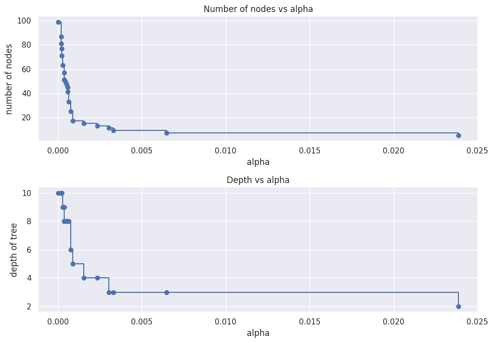

```python
# Remove the last element from the list of classifiers
clfs = clfs[:-1]

# Remove the last element from the list of ccp_alphas
ccp_alphas = ccp_alphas[:-1]

# Create a list of the number of nodes for each classifier in clfs
node_counts = [clf.tree_.node_count for clf in clfs]

# Create a list of the maximum depths for each classifier in clfs
depth = [clf.tree_.max_depth for clf in clfs]

# Create a figure with two subplots (one for number of nodes vs alpha and one for depth vs alpha)
fig, ax = plt.subplots(2, 1, figsize=(10, 7))

# Plot the number of nodes vs alpha in the first subplot
ax[0].plot(ccp_alphas, node_counts, marker="o", drawstyle="steps-post")
ax[0].set_xlabel("alpha")
ax[0].set_ylabel("number of nodes")
ax[0].set_title("Number of nodes vs alpha")

# Plot the depth of the tree vs alpha in the second subplot
ax[1].plot(ccp_alphas, depth, marker="o", drawstyle="steps-post")
ax[1].set_xlabel("alpha")
ax[1].set_ylabel("depth of tree")
ax[1].set_title("Depth vs alpha")

# Adjust the layout of the figure to prevent overlap
fig.tight_layout()
```

## Recall vs alpha for training and testing sets

```python
# Initialize an empty list to store recall scores for the training data
recall_train = []

# Loop through each classifier in the list of classifiers
for clf in clfs:
    # Predict the training data using the current classifier
    pred_train = clf.predict(X_train)

    # Calculate the recall score for the training data predictions
    values_train = recall_score(y_train, pred_train)

    # Append the recall score to the recall_train list
    recall_train.append(values_train)

# Initialize an empty list to store recall scores for the test data
recall_test = []

# Loop through each classifier in the list of classifiers
for clf in clfs:
    # Predict the test data using the current classifier
    pred_test = clf.predict(X_test)

    # Calculate the recall score for the test data predictions
    values_test = recall_score(y_test, pred_test)

    # Append the recall score to the recall_test list
    recall_test.append(values_test)
```

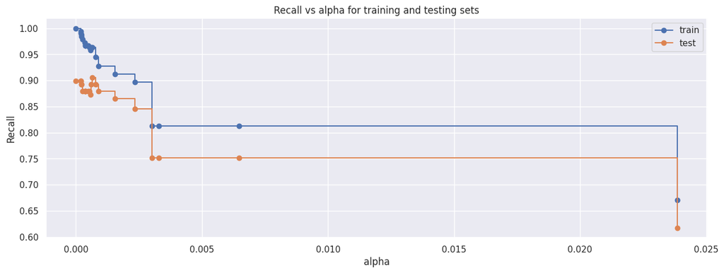

```python
# Create a figure and axis object with specified size (15 inches wide, 5 inches tall)
fig, ax = plt.subplots(figsize=(15, 5))

# Set the x-axis label
ax.set_xlabel("alpha")

# Set the y-axis label
ax.set_ylabel("Recall")

# Set the title of the plot
ax.set_title("Recall vs alpha for training and testing sets")

# Plot the recall scores for the training set
# Use blue circles as markers and a step-style line
ax.plot(ccp_alphas, recall_train, marker="o", label="train", drawstyle="steps-post")

# Plot the recall scores for the test set
# Use orange circles as markers and a step-style line
ax.plot(ccp_alphas, recall_test, marker="o", label="test", drawstyle="steps-post")

# Add a legend to distinguish between train and test lines
ax.legend()

# Display the plot
plt.show()
```

```python
# Find the index of the classifier with the highest recall score on the test data
index_best_model = np.argmax(recall_test)

# Select the classifier with the highest recall score on the test data
best_model = clfs[index_best_model]

# Print the details of the best classifier
print("Best model index:", index_best_model)
print("Best model type:", type(best_model))
print("Best model parameters:")
for param, value in best_model.get_params().items():
    print(f"  {param}: {value}")

# Print feature importances
if hasattr(best_model, 'feature_importances_'):
    print("\nFeature Importances:")
    for feature, importance in zip(X_train.columns, best_model.feature_importances_):
        print(f"  {feature}: {importance}")
```

```
Best model index: 14
Best model type: <class 'sklearn.tree._classes.DecisionTreeClassifier'>
Best model parameters:
  ccp_alpha: 0.0006414326414326415
  class_weight: None
  criterion: gini
  max_depth: None
  max_features: None
  max_leaf_nodes: None
  min_impurity_decrease: 0.0
  min_samples_leaf: 1
  min_samples_split: 2
  min_weight_fraction_leaf: 0.0
  random_state: 1
  splitter: best

Feature Importances:
  Age: 0.01716306090970831
  Income: 0.3190125472761435
  Family: 0.16485198876572466
  CCAvg: 0.045185370331316074
  Mortgage: 0.0
  Securities_Account: 0.0
  CD_Account: 0.02429818267912022
  Online: 0.0
  CreditCard: 0.0
  ZIPCode_91: 0.0
  ZIPCode_92: 0.0
  ZIPCode_93: 0.0
  ZIPCode_94: 0.0
  ZIPCode_95: 0.0
  ZIPCode_96: 0.0
  Education_Graduate: 0.0
  Education_Undergraduate: 0.4294888500379874
```

## Post Pruning

```python
# Create a new DecisionTreeClassifier with the ccp_alpha value from the best model identified earlier,
# specified class weights, and a fixed random state for reproducibility
estimator_2 = DecisionTreeClassifier(
    ccp_alpha=best_model.ccp_alpha,  # Use the ccp_alpha value from the best model
    class_weight={0: 0.15, 1: 0.85},  # Assign class weights to handle class imbalance
    random_state=1  # Set random state for reproducibility
)

# Fit the new classifier to the training data (X_train and y_train)
estimator_2.fit(X_train, y_train)
```

```
DecisionTreeClassifier(ccp_alpha=0.0006414326414326415,
                       class_weight={0: 0.15, 1: 0.85}, random_state=1)
```

### Check the performance on training data

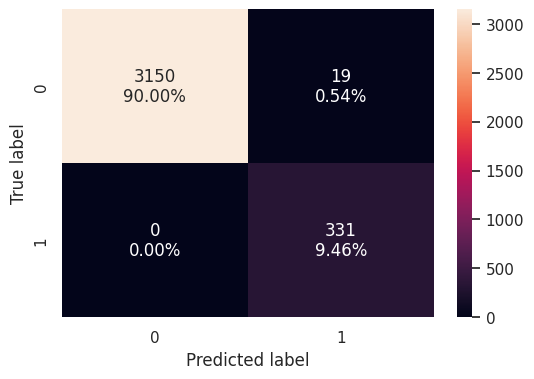

```python
# Compute and display the confusion matrix for the training set
confusion_matrix_sklearn(estimator_2, X_train, y_train)
```

```python
# Compute and display the performance metrics for the training set
decision_tree_perf_train = model_performance_classification_sklearn(
    estimator_2, X_train, y_train
)
# Display the performance metrics
decision_tree_perf_train
```

|  | Accuracy | Recall | Precision | F1 |
| --- | --- | --- | --- | --- |
| 0 | 0.994571 | 1.0 | 0.945714 | 0.9721 |

### Visualizing the Decision Tree

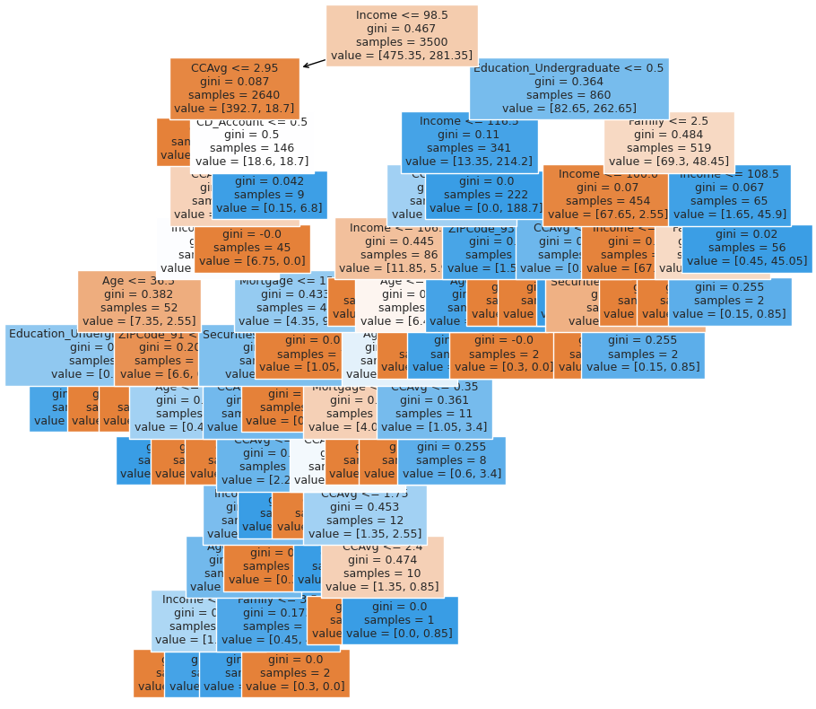

```python
# Set up the figure size for the plot
plt.figure(figsize=(10, 10))

# Plot the decision tree using the specified estimator and configuration
out = tree.plot_tree(
    estimator_2,                # The decision tree classifier to plot
    feature_names=feature_names,  # Names of the features used in the decision tree
    filled=True,                # Color the nodes to reflect the majority class
    fontsize=9,                 # Set the font size for the text in the plot
    node_ids=False,             # Do not display node IDs
    class_names=None            # Do not display class names
)

# Loop through the plotted tree elements to add arrows to the decision tree splits if they are missing
for o in out:
    arrow = o.arrow_patch
    if arrow is not None:
        arrow.set_edgecolor("black")  # Set the edge color of the arrows to black
        arrow.set_linewidth(1)        # Set the line width of the arrows to 1

# Display the plot
plt.show()
```

```python
# Text report showing the rules of a decision tree -

print(tree.export_text(estimator_2, feature_names=feature_names, show_weights=True))
```

```
|--- Income <= 98.50
|   |--- CCAvg <= 2.95
|   |   |--- weights: [374.10, 0.00] class: 0
|   |--- CCAvg >  2.95
|   |   |--- CD_Account <= 0.50
|   |   |   |--- CCAvg <= 3.95
|   |   |   |   |--- Income <= 81.50
|   |   |   |   |   |--- Age <= 36.50
|   |   |   |   |   |   |--- Education_Undergraduate <= 0.50
|   |   |   |   |   |   |   |--- weights: [0.15, 1.70] class: 1
|   |   |   |   |   |   |--- Education_Undergraduate >  0.50
|   |   |   |   |   |   |   |--- weights: [0.60, 0.00] class: 0
|   |   |   |   |   |--- Age >  36.50
|   |   |   |   |   |   |--- ZIPCode_91 <= 0.50
|   |   |   |   |   |   |   |--- weights: [6.15, 0.00] class: 0
|   |   |   |   |   |   |--- ZIPCode_91 >  0.50
|   |   |   |   |   |   |   |--- Age <= 46.00
|   |   |   |   |   |   |   |   |--- weights: [0.00, 0.85] class: 1
|   |   |   |   |   |   |   |--- Age >  46.00
|   |   |   |   |   |   |   |   |--- weights: [0.45, 0.00] class: 0
|   |   |   |   |--- Income >  81.50
|   |   |   |   |   |--- Mortgage <= 152.00
|   |   |   |   |   |   |--- Securities_Account <= 0.50
|   |   |   |   |   |   |   |--- CCAvg <= 3.05
|   |   |   |   |   |   |   |   |--- weights: [0.45, 0.00] class: 0
|   |   |   |   |   |   |   |--- CCAvg >  3.05
|   |   |   |   |   |   |   |   |--- CCAvg <= 3.85
|   |   |   |   |   |   |   |   |   |--- Income <= 93.50
|   |   |   |   |   |   |   |   |   |   |--- Age <= 45.50
|   |   |   |   |   |   |   |   |   |   |   |--- truncated branch of depth 2
|   |   |   |   |   |   |   |   |   |   |--- Age >  45.50
|   |   |   |   |   |   |   |   |   |   |   |--- truncated branch of depth 2
|   |   |   |   |   |   |   |   |   |--- Income >  93.50
|   |   |   |   |   |   |   |   |   |   |--- weights: [0.30, 0.00] class: 0
|   |   |   |   |   |   |   |   |--- CCAvg >  3.85
|   |   |   |   |   |   |   |   |   |--- weights: [0.00, 2.55] class: 1
|   |   |   |   |   |   |--- Securities_Account >  0.50
|   |   |   |   |   |   |   |--- weights: [0.60, 0.00] class: 0
|   |   |   |   |   |--- Mortgage >  152.00
|   |   |   |   |   |   |--- weights: [1.05, 0.00] class: 0
```

[output cut: 51 more lines]

```
|   |   |   |   |--- Income <= 103.50
|   |   |   |   |   |--- Securities_Account <= 0.50
|   |   |   |   |   |   |--- weights: [2.10, 0.00] class: 0
|   |   |   |   |   |--- Securities_Account >  0.50
|   |   |   |   |   |   |--- weights: [0.15, 0.85] class: 1
|   |   |   |   |--- Income >  103.50
|   |   |   |   |   |--- weights: [64.95, 0.00] class: 0
|   |   |--- Family >  2.50
|   |   |   |--- Income <= 108.50
|   |   |   |   |--- Family <= 3.50
|   |   |   |   |   |--- weights: [1.05, 0.00] class: 0
|   |   |   |   |--- Family >  3.50
|   |   |   |   |   |--- weights: [0.15, 0.85] class: 1
|   |   |   |--- Income >  108.50
|   |   |   |   |--- weights: [0.45, 45.05] class: 1
```

```python
# #Create and print a DataFrame of feature importances
# 1. Extract feature importances from the model
# 2. Create a DataFrame with importances and feature names computed as the  Gini importance
# 3. Display the result
print(
    pd.DataFrame(
        estimator_2.feature_importances_, columns=["Imp"], index=X_train.columns
    ).sort_values(by="Imp", ascending=False)
)
```

```
                              Imp
Income                   0.602209
Family                   0.144151
Education_Undergraduate  0.127332
CCAvg                    0.089356
Age                      0.011925
CD_Account               0.011166
Mortgage                 0.004929
Securities_Account       0.004788
ZIPCode_91               0.002635
ZIPCode_93               0.001508
Online                   0.000000
CreditCard               0.000000
ZIPCode_92               0.000000
ZIPCode_94               0.000000
ZIPCode_95               0.000000
ZIPCode_96               0.000000
Education_Graduate       0.000000
```

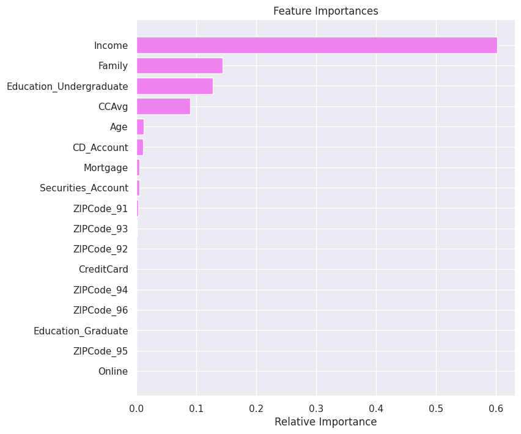

```python
# Calculate feature importances from the trained estimator
importances = estimator_2.feature_importances_

# Sort feature indices based on their importances
indices = np.argsort(importances)

# Create a figure for plotting with a specific size
plt.figure(figsize=(8, 8))

# Set the title of the plot
plt.title("Feature Importances")

# Create a horizontal bar plot to visualize feature importances
plt.barh(range(len(indices)), importances[indices], color="violet", align="center")

# Set y-axis tick labels to display feature names corresponding to their indices
plt.yticks(range(len(indices)), [feature_names[i] for i in indices])

# Set the label for the x-axis
plt.xlabel("Relative Importance")

# Display the plot
plt.show()
```

### Checking performance on the test data

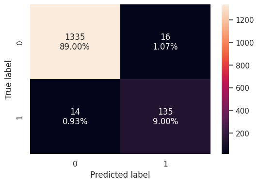

```python
# Compute and display the confusion matrix for the test set
confusion_matrix_sklearn(estimator_2, X_test, y_test)
```

```python
# Compute the performance metrics for the test set
decision_tree_perf_test = model_performance_classification_sklearn(
    estimator_2, X_test, y_test
)
# Display the performance metrics
decision_tree_perf_test
```

|  | Accuracy | Recall | Precision | F1 |
| --- | --- | --- | --- | --- |
| 0 | 0.98 | 0.90604 | 0.89404 | 0.9 |

## Model Performance Comparison and Final Model Selection

```python
# Training performance comparison
# Combine the performance metrics of the original decision tree and the tuned (pre-pruned) decision tree
models_train_comp_df = pd.concat(
    [decision_tree_perf_train.T, decision_tree_tune_perf_train.T], axis=1,
)

# Set column names for the combined dataframe
models_train_comp_df.columns = ["Decision Tree sklearn", "Decision Tree (Pre-Pruning)"]

# Print a header for the comparison
print("Training performance comparison:")

# Display the comparison dataframe
models_train_comp_df
```

```
Training performance comparison:
```

|  | Decision Tree sklearn | Decision Tree (Pre-Pruning) |
| --- | --- | --- |
| Accuracy | 0.994571 | 0.990286 |
| Recall | 1.000000 | 0.927492 |
| Precision | 0.945714 | 0.968454 |
| F1 | 0.972100 | 0.947531 |

```python
# Compare the testing performance of the original decision tree and the tuned (pre-pruned) decision tree

models_test_comp_df = pd.concat(
    [decision_tree_perf_test.T, decision_tree_tune_perf_test.T], axis=1,)

# Set column names for the combined dataframe
models_test_comp_df.columns = ["Decision Tree sklearn", "Decision Tree (Pre-Pruning)"]

# Print a header for the comparison
print("Test performance comparison:")

# Display the comparison dataframe
models_test_comp_df
```

```
Test performance comparison:
```

|  | Decision Tree sklearn | Decision Tree (Pre-Pruning) |
| --- | --- | --- |
| Accuracy | 0.98000 | 0.980000 |
| Recall | 0.90604 | 0.865772 |
| Precision | 0.89404 | 0.928058 |
| F1 | 0.90000 | 0.895833 |

## Actionable Insights and Business Recommendations

# Expolatory Data Analysis observations

- Income is right-skewed and has many outliers above the 3rd quartile.
- CCAvg is right-skewed and has many outliers above the 3rd quartile.
- Mortgage is heavily right-skewed and there are many outliers above the 3rd quartile in this variable.
- 29.4% of customers have one child, and only 20.2% of customers have three children.
- The majority (42%) of customers have an undergraduate level of education.
- 89.6% of customers do not have a securities account
- 94% of customers do not have a CD account
- 59% of users do their banking online
- 70% of customers do not have a credit card
- The majority of customers (29.4%) live in area 94.
- Very few customers (0.8%) live in area 96
- There is an extremely strong correlation (0.99) between age and experience.
- There is a strong correlation (.65) between income and credit card average.
- 90% of customers do not have a personal loan
- Customers with advanced/professional degrees are about three times more likely to have a personal loan than those with undergraduate degrees.
- Education of advanced/professional and graduates have similar rates of personal loans, both significantly higher than undergraduate.
- 90.4% of families do not have a personal loan
- Larger families (3 -4 persons) seem to have a higher percentage of personal loans compared to smaller families (1- 2 persons)
- 89.6% of customers do not have a securities account
- There is a slightly higher percentage of securities account holders among those with personal loans (12.5%) than those without (10.22%).
- 93% of customers do not have a CD account.
- There seems to be a higher proportion of individuals with personal loans among those with a CD account than those who do not have a CD account.
- 59.68% of customers use online banking
- Online banking is more popular than traditional banking in this dataset, regardless of loan status
- 70.6% of customers do not have a credit card.
- Credit card ownership rates are similar between those customers with personal loans and those without.
- ZIP code 94 has the highest population (1472, 29.44% of the sample).
- ZIP code 96 has the lowest population (40, 0.8% of the sample).
- Personal loan rates are relatively consistent across most ZIP codes, ranging from 9.37% to 10.31% for ZIP codes 90-95.
- Income, CCAvg, and Mortgage have a significant number of values above the 3rd quartile that are considered outliers. However, these values are legitimate and do not require outlier treatment.
- There is a drop of in personal loans as the customers have more experience.

# Analysis of Model Performance for AllLife Bank

## Importance of Recall

- **Recall is the most critical metric** for AllLife Bank's objective of expanding its borrower base and converting liability customers to personal loan customers.
- Recall measures the proportion of actual positive cases (potential loan customers) correctly identified.
- A high recall indicates the model excels at identifying potential loan customers.

## Strategy Justification

- It's more beneficial to reach out to a larger pool of potential customers, even if some don't take loans than to miss potential loan customers.

This will maximize the number of customers who are likely to take out a personal loan, which should lead to a higher number of customers taking out a personal loan.

## Recommendations

**Feature Importance:**

- Focus marketing efforts on the most influential features for loan acceptance. Based on the feature importance of this model, income, and family size are top factors, tailoring marketing messages around financial stability and family financial planning.

**Address Class Imbalance:** Given that borrowers are a small portion of the customer base, consider techniques to address class imbalance, such as:

- Oversampling the minority class (borrowers)
- Undersampling the majority class (non-borrowers)

**Targeted Marketing:**

- Use the insights from the model to create more targeted marketing campaigns. For example, if certain age groups or income levels are more likely to take loans, focus efforts there.

**Cross-Selling Strategy:**

- Develop a strategy to cross-sell personal loans to existing liability customers. Use the model to identify which depositors are most likely interested in loans.

**Customer Segmentation:**

- Use the model insights to create customer segments. Tailor product offerings and marketing messages to each segment's characteristics and needs.

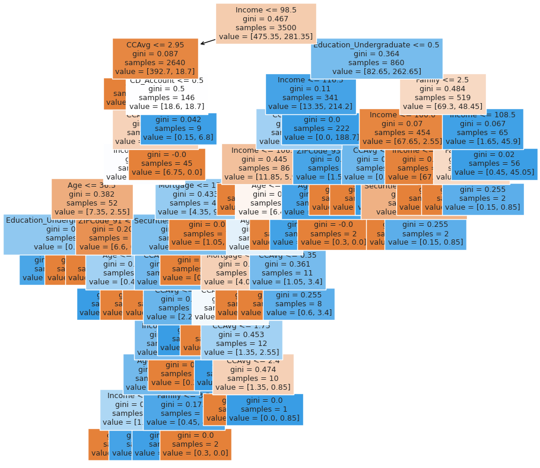

```python
#This is the visualiztion of the Post Prune tree that is the model that should be used
# Set up the figure size for the plot
plt.figure(figsize=(10, 10))

# Plot the decision tree using the specified estimator and configuration
out = tree.plot_tree(
    estimator_2,                # The decision tree classifier to plot
    feature_names=feature_names,  # Names of the features used in the decision tree
    filled=True,                # Color the nodes to reflect the majority class
    fontsize=9,                 # Set the font size for the text in the plot
    node_ids=False,             # Do not display node IDs
    class_names=None            # Do not display class names
)

# Loop through the plotted tree elements to add arrows to the decision tree splits if they are missing
for o in out:
    arrow = o.arrow_patch
    if arrow is not None:
        arrow.set_edgecolor("black")  # Set the edge color of the arrows to black
        arrow.set_linewidth(1)        # Set the line width of the arrows to 1

# Display the plot
plt.show()
```

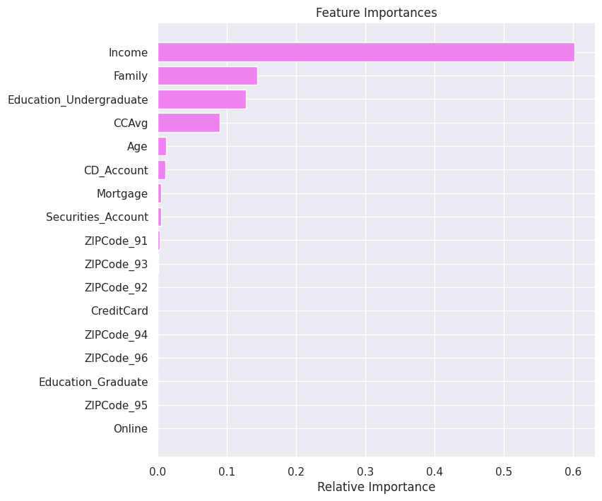

```python
# This is the importance for the post prune model
# Calculate feature importances from the trained estimator
importances = estimator_2.feature_importances_

# Sort feature indices based on their importances
indices = np.argsort(importances)

# Create a figure for plotting with a specific size
plt.figure(figsize=(8, 8))

# Set the title of the plot
plt.title("Feature Importances")

# Create a horizontal bar plot to visualize feature importances
plt.barh(range(len(indices)), importances[indices], color="violet", align="center")

# Set y-axis tick labels to display feature names corresponding to their indices
plt.yticks(range(len(indices)), [feature_names[i] for i in indices])

# Set the label for the x-axis
plt.xlabel("Relative Importance")

# Display the plot
plt.show()
```